# Machine Learning in Econometrics

Huan Deng

2025-10-31

> **How to use this file.** Each section begins with a short explanation (what/why), followed by an R chunk (how). All data are simulated, so it runs anywhere; packages auto-install if missing.

# 1 Basic Set-up

Load necessary packages

# 2 Showing Overfitting

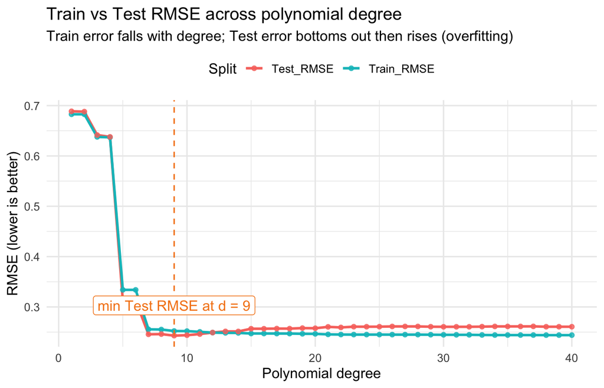

```r
# ---- overfit_degree_sweep_OLS_only: continuous MSE vs degree + clean raw-data panel ----
library(ggplot2)
library(dplyr)
library(tidyr)
library(patchwork)

# 1) Create 1-D toy data (if not present)
if (!exists("train_1d") || !exists("test_1d")) {
  set.seed(42)
  n  <- 1000
  x  <- runif(n, -1, 1)
  f  <- function(x) sin(2*pi*x)
  y  <- f(x) + rnorm(n, sd = 0.25)  # modest noise so overfitting is visible
  ix <- sample.int(n, floor(0.75*n))
  train_1d <- data.frame(x = x[ix],  y = y[ix],  split = "Train")
  test_1d  <- data.frame(x = x[-ix], y = y[-ix], split = "Test")
}

# 2) Fit OLS for degrees 1..Dmax using the same formula for predict()
Dmax <- 40
deg_seq <- 1:Dmax

fit_ols_deg <- function(d) {
  form <- as.formula(paste0("y ~ poly(x, ", d, ", raw = TRUE)"))
  fit  <- lm(form, data = train_1d)
  c(
    rmse_tr = sqrt(mean((train_1d$y - predict(fit, newdata = train_1d))^2)),
    rmse_te = sqrt(mean((test_1d$y  - predict(fit, newdata = test_1d ))^2))
  )
}

rmse_mat <- sapply(deg_seq, fit_ols_deg)
rmse_df  <- tibble(
  degree     = deg_seq,
  Train_RMSE = rmse_mat["rmse_tr", ],
  Test_RMSE  = rmse_mat["rmse_te", ]
)

# Pick best degree by minimum Test RMSE (for illustration)
best_idx <- which.min(rmse_df$Test_RMSE)
d_star   <- rmse_df$degree[best_idx]
d_hi     <- max(deg_seq)    # very high degree to show overfitting (e.g., 40)

# 3) Build fitted curves for a few selected degrees (1, d*, very high)
xg  <- seq(-1, 1, length.out = 400)
f_true <- sin(2*pi*xg)

ols_fit <- function(d) lm(as.formula(paste0("y ~ poly(x, ", d, ", raw = TRUE)")), data = train_1d)

fit1   <- ols_fit(1)
fitds  <- ols_fit(d_star)
fithi  <- ols_fit(d_hi)

curves <- tibble(
  x      = xg,
  Deg1   = predict(fit1,  newdata = data.frame(x = xg)),
  DegStar= predict(fitds, newdata = data.frame(x = xg)),
  DegHi  = predict(fithi, newdata = data.frame(x = xg))
) |>
  pivot_longer(-x, names_to = "Model", values_to = "yhat")

# 4) Panel A: Continuous RMSE vs degree (train & test) with minimum highlighted
panelA <- rmse_df |>
  pivot_longer(c(Train_RMSE, Test_RMSE), names_to = "Split", values_to = "RMSE") |>
  ggplot(aes(degree, RMSE, color = Split)) +
  geom_line(linewidth = 1) +
  geom_point(size = 1.5, alpha = 0.8) +
  geom_vline(xintercept = d_star, linetype = 2, color = "#F58518") +
  annotate("label", x = d_star, y = min(rmse_df$Test_RMSE),
           label = paste0("min Test RMSE at d = ", d_star),
           vjust = -1.1, fill = "white", color = "#F58518", label.size = 0.2) +
  labs(title = "Train vs Test RMSE across polynomial degree",
       subtitle = "Train error falls with degree; Test error bottoms out then rises (overfitting)",
       x = "Polynomial degree", y = "RMSE (lower is better)") +
  theme_minimal(base_size = 12) +
  theme(legend.position = "top")

# 5) Panel B: Clean raw-data plot + true curve + selected fitted curves
#    Keep y-axis within a sensible range so wiggles are visible without huge spikes.
y_range <- range(c(train_1d$y, test_1d$y, f_true))
y_pad   <- diff(y_range) * 0.25
ylim_use <- c(y_range[1] - y_pad, y_range[2] + y_pad)

# ---- Panel B (refined colors & styling) ----
# ---- Panel B (simple colors: blue/orange/red) ----
panelB <- ggplot() +
  # raw points (keep them neutral so curves pop)
  geom_point(aes(x, y), data = train_1d,
             color = "grey75", alpha = 0.7, size = 1.8) +
  geom_point(aes(x, y), data = test_1d,
             color = "grey30", alpha = 0.9, size = 2.2) +
  # true function
  geom_line(aes(xg, f_true), color = "black", linewidth = 1.1, alpha = 0.9) +
  # fitted curves: Deg1 (blue), DegStar (orange), DegHi (red)
  geom_line(
    aes(x, yhat, color = Model, linetype = Model),
    data = curves |> dplyr::filter(Model %in% c("Deg1","DegStar","DegHi")),
    linewidth = 1.2
  ) +
  scale_color_manual(
    values = c(
      Deg1    = "blue",    # low degree
      DegStar = "orange",  # best test degree
      DegHi   = "red"      # very high degree (overfitting)
    ),
    labels = c(
      Deg1    = "Degree 1 (low)",
      DegStar = paste0("Degree ", d_star, " (best Test)"),
      DegHi   = paste0("Degree ", d_hi, " (very high)")
    )
  ) +
  scale_linetype_manual(
    values = c(Deg1 = "solid", DegStar = "solid", DegHi = "dashed"),
    labels = c(
      Deg1    = "Degree 1 (low)",
      DegStar = paste0("Degree ", d_star, " (best Test)"),
      DegHi   = paste0("Degree ", d_hi, " (very high)")
    )
  ) +
  coord_cartesian(ylim = ylim_use) +
  labs(
    title    = "Raw data and fitted OLS curves",
    subtitle = "True f(x) in black. Very-high degree oscillates and chases noise.",
    x = "x", y = "y", color = "Curve", linetype = "Curve"
  ) +
  theme_minimal(base_size = 12) +
  theme(
    legend.position = "top",
    legend.title = element_text(size = 11),
    legend.text  = element_text(size = 10)
  )
# 6) Combine panels
panelA
```

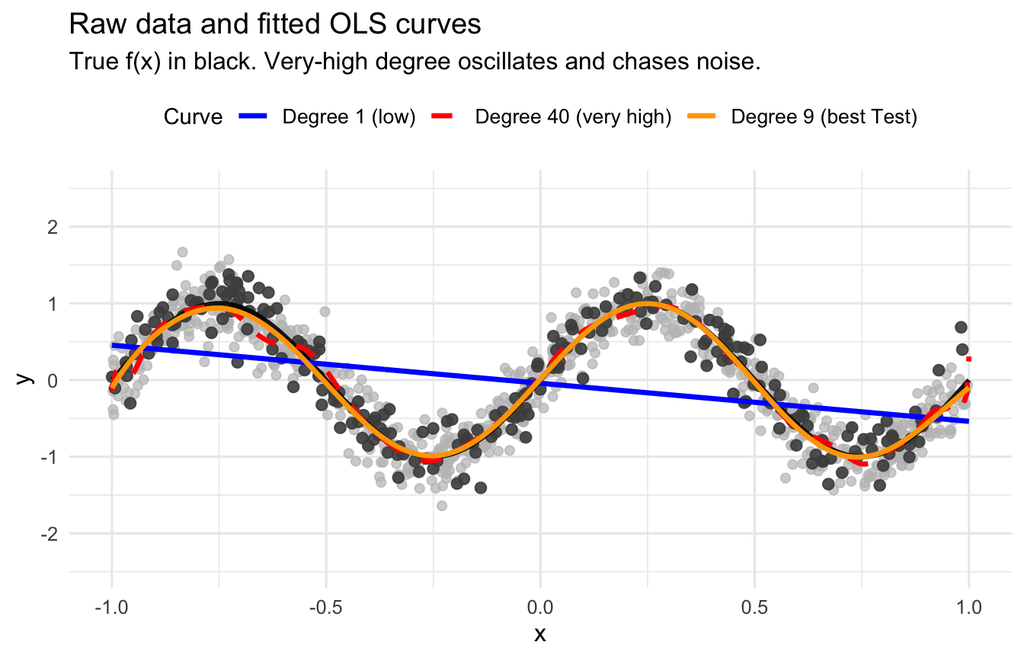

```r
panelB
```

# 3 Simulating Data

We simulate one re-usable dataset: covariates `X`, a *confounded* treatment `w` with propensity `e(X)`, a nonlinear baseline outcome `μ0(X)`, and heterogeneous treatment effects `τ(X)`. We also create train/test splits and `model.matrix` inputs (for glmnet) so every later section can share the same data-generating story.

```r
n  <- 3000
p  <- 10
X  <- matrix(rnorm(n * p), n, p)
colnames(X) <- paste0("x", 1:p)
Xdf <- as_tibble(X)

tau_fun <- function(x) 1 + 1.25 * (x[,1] > 0) + 0.5 * x[,2]              # τ(x)
mu0_fun <- function(x) 2*x[,1] + 0.5*x[,2]^2 - x[,3] + 0.5*x[,4]*x[,5]  # μ0(x)
logit   <- function(z) 1/(1+exp(-z))
e_fun   <- function(x) logit(-0.3 + 0.6*x[,1] - 0.4*x[,2] + 0.2*x[,3])  # P(W=1|X)

tau_true <- tau_fun(X)
mu0_true <- mu0_fun(X)
e_true   <- e_fun(X)

true_ATE_sim <- mean(tau_true)

W   <- rbinom(n, 1, e_true)     # confounded treatment
eps <- rnorm(n, 1, 1)
Y   <- mu0_true + tau_true * W + eps

data <- bind_cols(tibble(y = Y, w = W), Xdf)

# Train/test split for predictive sections

set.seed(123)
idx_train <- sample.int(n, size = floor(0.7*n))
train <- data[idx_train, ]
test  <- data[-idx_train, ]

# Model matrices for glmnet

X_train <- model.matrix(y ~ . , data = train)[, -1]
y_train <- train$y
X_test  <- model.matrix(y ~ . , data = test)[, -1]
y_test  <- test$y

tibble(
  True_ATE_sim = true_ATE_sim
)
```

| True_ATE_sim |
| --- |
| 1.620519 |

# 4 Ridge and Lasso

Cross-validated ridge (`α=0`) and lasso (`α=1`) are trained on the main dataset. We report test RMSE to contrast *dense* shrinkage (ridge) with *sparse* shrinkage (lasso). Use this to discuss when each is preferable (multicollinearity vs. variable selection).

```r
cv_ridge <- cv.glmnet(X_train, y_train, alpha = 0, nfolds = 10, standardize = TRUE)
cv_lasso <- cv.glmnet(X_train, y_train, alpha = 1, nfolds = 10, standardize = TRUE)

pred_ridge <- as.numeric(predict(cv_ridge, newx = X_test, s = "lambda.min"))
pred_lasso <- as.numeric(predict(cv_lasso, newx = X_test, s = "lambda.min"))

rmse_ridge <- sqrt(mean((y_test - pred_ridge)^2))
rmse_lasso <- sqrt(mean((y_test - pred_lasso)^2))

kableExtra::kable(tibble(Model = c("Ridge (λ_min)", "LASSO (λ_min)"),
Test_RMSE = c(rmse_ridge, rmse_lasso)), digits = 4)
```

| Model | Test_RMSE |
| --- | --- |
| Ridge (λ_min) | 1.4030 |
| LASSO (λ_min) | 1.3847 |

```r
nz_ridge <- sum(coef(cv_ridge, s = "lambda.min") != 0) - 1
nz_lasso <- sum(coef(cv_lasso, s = "lambda.min") != 0) - 1

tibble(Method = c("Ridge","LASSO"),
Nonzero_Coefficients = c(nz_ridge, nz_lasso))
```

| Method | Nonzero_Coefficients |
| --- | --- |
| Ridge | 11 |
| LASSO | 5 |

# 5 SVM

On a simple 2-D problem, we plot linear vs. RBF-kernel SVMs: decision boundary $f(x)=0$, margins $f(x)=\pm1$, and support vectors. The RBF kernel implements a distance-based similarity, enabling nonlinear separation; tune $(C,\gamma)$ by CV.

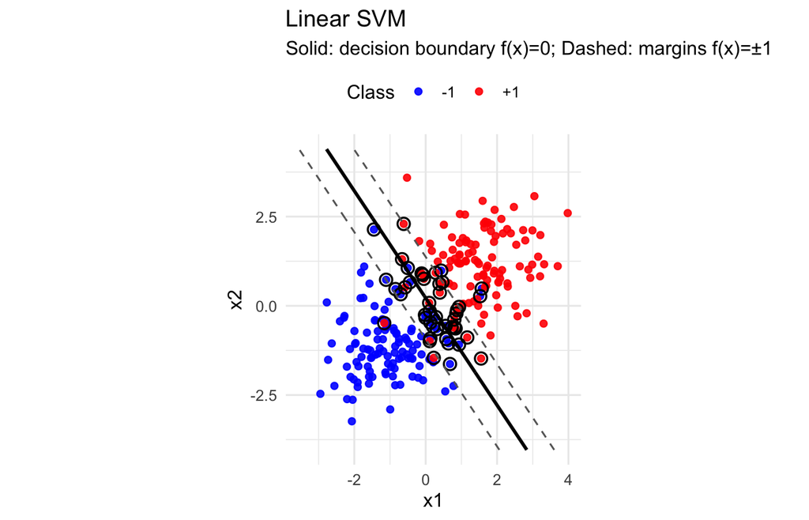

```r
# ---- svm_demo_plots: linear vs RBF SVM with decision boundary/margins ----
library(e1071)
library(ggplot2)
library(dplyr)
library(patchwork)

set.seed(123)

# 1) Make a 2-D toy dataset with two partly overlapping blobs
n   <- 120
mu1 <- c(-1.0, -1.0)
mu2 <- c( 1.3,  1.1)
Sigma <- matrix(c(1, 0.25, 0.25, 1), 2, 2)
gen <- function(mu, n) {
  Z <- matrix(rnorm(2*n), 2, n)
  t(matrix(mu, nrow = 2, ncol = n) + chol(Sigma) %*% Z)
}
A <- gen(mu1, n); B <- gen(mu2, n)
df <- bind_rows(
  tibble(x1 = A[,1], x2 = A[,2], y = factor(-1, levels = c(-1, 1))),
  tibble(x1 = B[,1], x2 = B[,2], y = factor( 1, levels = c(-1, 1)))
)

# Utility to make a dense grid around the data
make_grid <- function(dat, padding = 0.8, len = 300) {
  xr <- range(dat$x1); yr <- range(dat$x2)
  xs <- seq(xr[1] - padding, xr[2] + padding, length.out = len)
  ys <- seq(yr[1] - padding, yr[2] + padding, length.out = len)
  expand.grid(x1 = xs, x2 = ys)
}

grid_xy <- make_grid(df)

# 2) Fit SVMs
svm_lin <- svm(y ~ x1 + x2, data = df,
               kernel = "linear", cost = 1, scale = TRUE,
               type = "C-classification")
svm_rbf <- svm(y ~ x1 + x2, data = df,
               kernel = "radial", gamma = 1, cost = 1, scale = TRUE,
               type = "C-classification")

# 3) Get decision values f(x) on a grid (needed for boundary/margins)
pred_lin <- predict(svm_lin, grid_xy, decision.values = TRUE)
dv_lin   <- attr(pred_lin, "decision.values")    # f(x) for linear SVM

pred_rbf <- predict(svm_rbf, grid_xy, decision.values = TRUE)
dv_rbf   <- attr(pred_rbf, "decision.values")    # f(x) for RBF SVM

grid_lin <- cbind(grid_xy, f = as.numeric(dv_lin))
grid_rbf <- cbind(grid_xy, f = as.numeric(dv_rbf))

# Indices of support vectors (to highlight)
sv_idx_lin <- svm_lin$index
sv_idx_rbf <- svm_rbf$index

# 4) Plot: Linear SVM (left)
p_lin <- ggplot(df, aes(x1, x2)) +
  # training points
  geom_point(aes(color = y), size = 1.7, alpha = 0.9) +
  # support vectors outlined
  geom_point(data = df[sv_idx_lin, ], shape = 21, size = 3,
             stroke = 0.9, color = "black", fill = NA) +
  # decision boundary f(x)=0 (solid) and margins f=±1 (dashed)
  geom_contour(data = grid_lin, aes(z = f), breaks = 0, color = "black", size = 1) +
  geom_contour(data = grid_lin, aes(z = f), breaks = c(-1, 1),
               color = "grey40", linetype = "dashed") +
  scale_color_manual(values = c(`-1` = "blue", `1` = "red"),
                     name = "Class", labels = c("-1", "+1")) +
  coord_equal() +
  labs(title = "Linear SVM", x = "x1", y = "x2",
       subtitle = "Solid: decision boundary f(x)=0; Dashed: margins f(x)=±1") +
  theme_minimal(base_size = 12) +
  theme(legend.position = "top")

# 5) Plot: RBF SVM (right)
p_rbf <- ggplot(df, aes(x1, x2)) +
  geom_point(aes(color = y), size = 1.7, alpha = 0.9) +
  geom_point(data = df[sv_idx_rbf, ], shape = 21, size = 3,
             stroke = 0.9, color = "black", fill = NA) +
  geom_contour(data = grid_rbf, aes(z = f), breaks = 0, color = "black", size = 1) +
  geom_contour(data = grid_rbf, aes(z = f), breaks = c(-1, 1),
               color = "grey40", linetype = "dashed") +
  scale_color_manual(values = c(`-1` = "blue", `1` = "red"),
                     name = "Class", labels = c("-1", "+1")) +
  coord_equal() +
  labs(title = "RBF (Gaussian) SVM", x = "x1", y = "x2",
       subtitle = "Nonlinear boundary; support vectors circled") +
  theme_minimal(base_size = 12) +
  theme(legend.position = "none")

p_lin
```

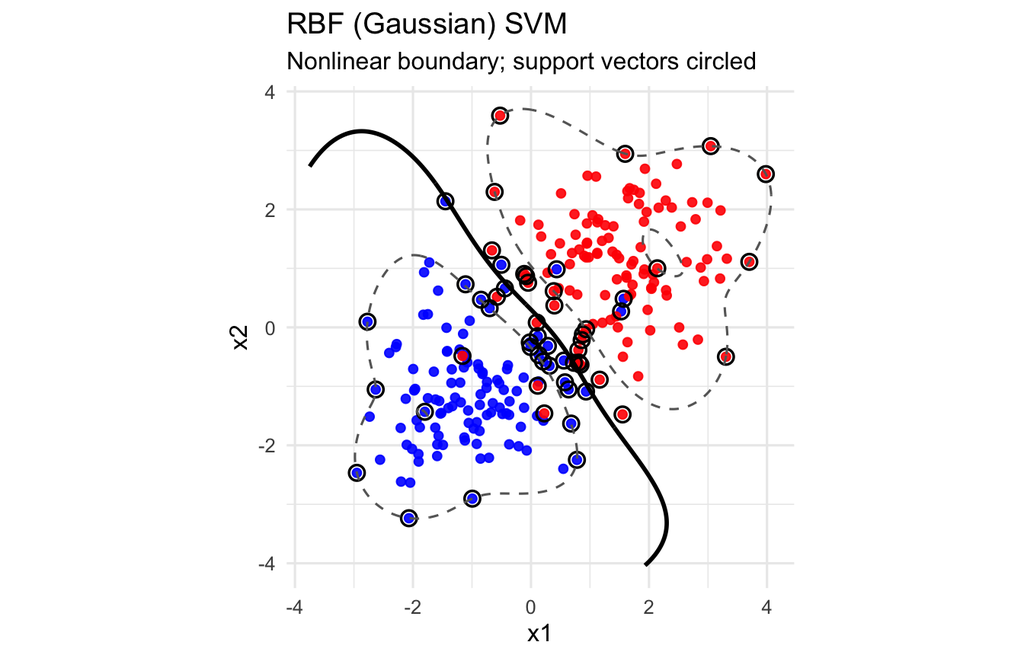

```r
p_rbf
```

# 6 Clustering

A short tour of unsupervised learning. We cluster a synthetic 5-D dataset with K-means; in practice you should standardize features (here we handle that in the plotting pipeline). This sets up the elbow and silhouette diagnostics.

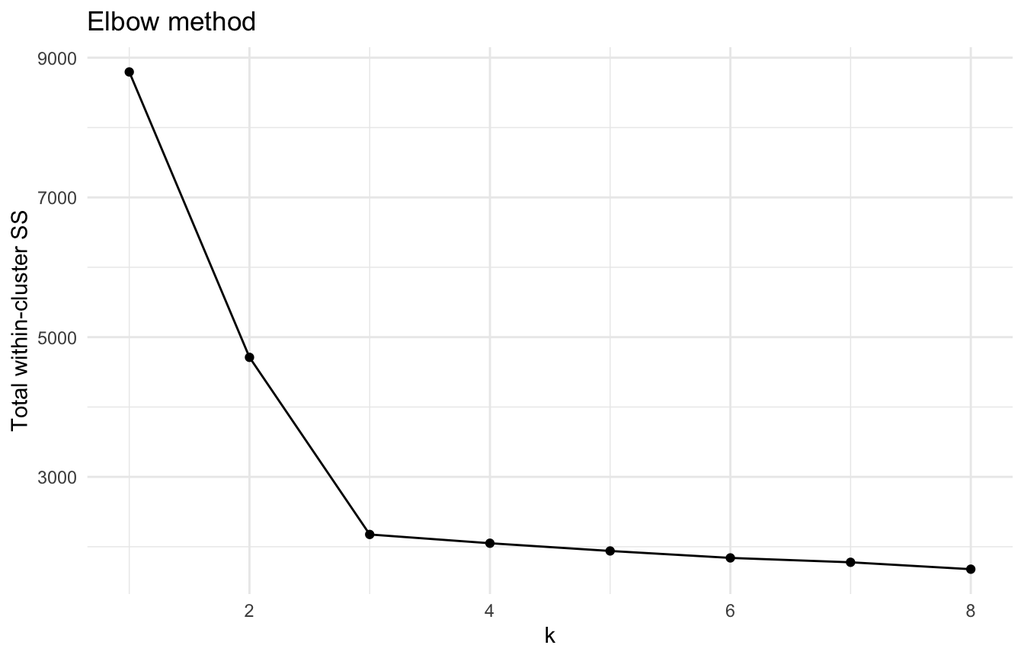

```r
set.seed(7)
n_k <- 900
centers <- matrix(c(2,2,0,0,0,
-2,0,2,0,0,
0,-2,0,2,0), ncol = 5, byrow = TRUE)
cl <- sample(1:3, n_k, replace = TRUE, prob = c(0.35, 0.35, 0.30))
Xk <- matrix(rnorm(n_k * 5, sd = 0.7), n_k, 5) + centers[cl, ]
dfk <- as_tibble(Xk)


wcss <- function(k){kmeans(dfk, centers = k, nstart = 20)$tot.withinss}
ks <- 1:8
elbow_vals <- sapply(ks, wcss)
tibble(k = ks, tot_within_ss = elbow_vals) %>%
ggplot(aes(k, tot_within_ss)) + geom_line() + geom_point() +
labs(title = "Elbow method", x = "k", y = "Total within-cluster SS")
```

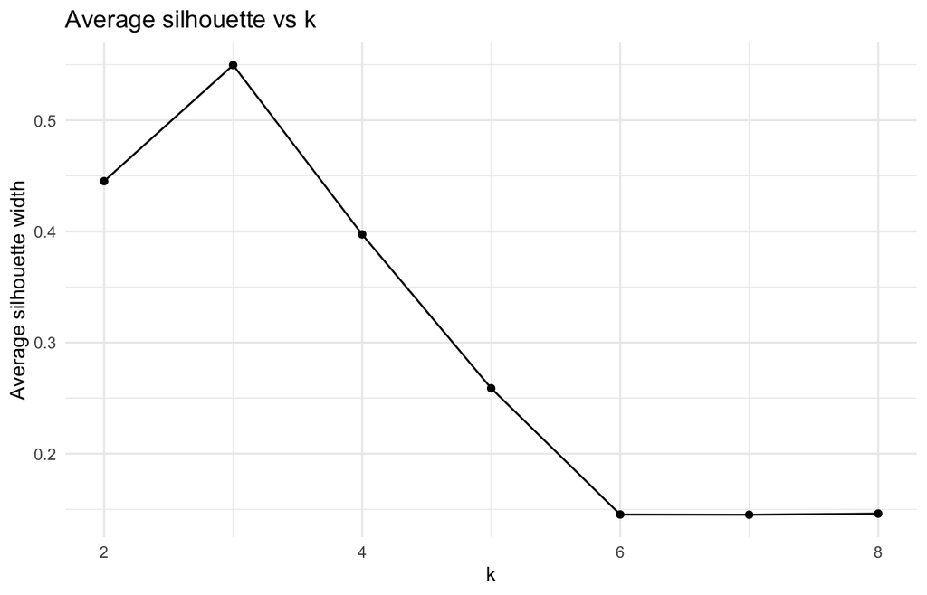

```r
sil_of_k <- function(k){
km <- kmeans(dfk, centers = k, nstart = 20)
ss <- cluster::silhouette(km$cluster, dist(dfk))
mean(ss[,3])
}
sil_vals <- sapply(2:8, sil_of_k)
tibble(k = 2:8, avg_sil = sil_vals) %>%
ggplot(aes(k, avg_sil)) + geom_line() + geom_point() +
labs(title = "Average silhouette vs k", x = "k", y = "Average silhouette width")
```

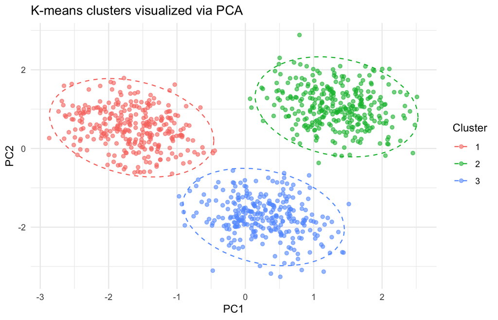

```r
set.seed(7)
km3 <- kmeans(dfk, centers = 3, nstart = 50)
pc   <- prcomp(dfk, center = TRUE, scale. = TRUE)
df_plot <- as_tibble(pc$x[,1:2]) %>% mutate(cluster = factor(km3$cluster))

ggplot(df_plot, aes(PC1, PC2, color = cluster)) +
geom_point(alpha = 0.6) +
stat_ellipse(type = "norm", linetype = 2, linewidth = 0.5) +
labs(title = "K-means clusters visualized via PCA", color = "Cluster")
```

# 7 Causal Forest

Fits `grf::causal_forest` on `(X, y, w)` with *honesty* and internal *orthogonalization*. We predict individualized treatment effects on the test set and report a forest-based ATE with a valid standard error. This is the “who benefits more?” piece.

```r
Xmat <- as.matrix(data %>% dplyr::select(starts_with("x")))

cf <- causal_forest(
X = Xmat, Y = data$y, W = data$w,
num.trees = 2000, min.node.size = 5, honesty = TRUE, seed = 123
)

Xmat_test <- as.matrix(test %>% dplyr::select(starts_with("x")))
tau_hat   <- predict(cf, Xmat_test)$predictions

ate_cf <- average_treatment_effect(cf, target.sample = "all")
ate_cf
```

```
##   estimate    std.err
## 1.51798765 0.05137133
```

The forest learns a complex $\hat\tau(x)$. BLP projects it onto a simple linear summary over chosen features, yielding a table of coefficients. The intercept is a linearized baseline (close to ATE if features are centered); slopes show how effects vary with each covariate. This gives an interpretable “gradient of heterogeneity.”

```r
# BLP summary of heterogeneity (robust to grf version differences)
# ---- Robust Best Linear Projection (works across grf versions) ----
# Try the (X, Y, W) signature first; fall back to (X) only if needed.
blp_obj <- tryCatch(
  grf::best_linear_projection(cf, Xmat, data$y, data$w),
  error = function(e) try(grf::best_linear_projection(cf, Xmat), silent = TRUE)
)

# Helper to extract a tidy coefficient table regardless of returned type
tidy_blp <- function(blp, X) {
  # Case 1: list with $coef (many grf versions)
  if (is.list(blp) && !is.null(blp$coef)) {
    est <- as.numeric(blp$coef)
    nm  <- names(blp$coef)
    return(tibble::tibble(term = nm, estimate = est))
  }
  # Case 2: matrix (coeffs in first column; rownames are terms if present)
  if (is.matrix(blp)) {
    est <- as.numeric(blp[, 1, drop = TRUE])
    nm  <- rownames(blp)
    if (is.null(nm)) {
      # Guess names: intercept + X colnames
      nm <- c("(Intercept)", colnames(X))
      if (length(nm) != length(est)) nm <- paste0("beta", seq_along(est))
    }
    return(tibble::tibble(term = nm, estimate = est))
  }
  # Case 3: plain numeric vector
  if (is.numeric(blp)) {
    est <- as.numeric(blp)
    # Try to infer whether there is an intercept
    if (length(est) == ncol(X) + 1) {
      nm <- c("(Intercept)", colnames(X))
    } else if (length(est) == ncol(X)) {
      nm <- colnames(X)
    } else {
      nm <- paste0("beta", seq_along(est))
    }
    return(tibble::tibble(term = nm, estimate = est))
  }
  # Fallback: show structure so you can see what came back
  str(blp)
  stop("Unexpected return type from best_linear_projection().")
}

blp_tbl <- tidy_blp(blp_obj, Xmat)
blp_tbl
```

| term | estimate |
| --- | --- |
| (Intercept) | 1.528724256 |
| x1 | 0.490949969 |
| x2 | 0.367359057 |
| x3 | 0.022978103 |
| x4 | -0.011483358 |
| x5 | 0.075722974 |
| x6 | -0.001870074 |
| x7 | 0.000139710 |
| x8 | -0.025497837 |
| x9 | 0.021493444 |

[output cut: 1 more lines]

# 8 Double Machine Learning (DML)

Implements DML under selection on observables: cross-fitted outcome and propensity models feed an *orthogonal* AIPW score, delivering a $\sqrt{n}$-consistent ATE with valid SEs. Emphasize why cross-fitting (out-of-fold nuisances) removes first-order regularization bias.

```r
library(data.table)  # DoubleML expects a data.table

dml_df <- data %>%
dplyr::select(y, d = w, dplyr::starts_with("x")) %>%
dplyr::mutate(d = as.numeric(d)) %>%
data.table::as.data.table()

dml_data <- DoubleMLData$new(dml_df, y_col = "y", d_cols = "d")

ml_g <- lrn("regr.ranger", num.trees = 1000, min.node.size = 5)
ml_m <- lrn("classif.ranger", predict_type = "prob", num.trees = 1000, min.node.size = 5)

dml_irm <- DoubleMLIRM$new(dml_data, ml_g = ml_g, ml_m = ml_m, n_folds = 5, score = "ATE")
dml_irm$fit()
dml_irm$summary()
```

```
## Estimates and significance testing of the effect of target variables
##   Estimate. Std. Error t value Pr(>|t|)
## d   1.58125    0.05584   28.32   <2e-16 ***
## ---
## Signif. codes:  0 '***' 0.001 '**' 0.01 '*' 0.05 '.' 0.1 ' ' 1
```

Implememting DML manually

```r
# ---- Manual DML (aligned to DoubleML; order-robust) ----
# Goal: produce a manual DML estimate that matches DoubleML by using the same
# sample splitting (folds), trimming, and comparable learners/hyper-params.

# 0) Ensure data/learners exist (re-create if the user ran this chunk first)
if (!exists("dml_df")) {
  library(data.table)
  dml_df <- data %>%
    dplyr::select(y, d = w, dplyr::starts_with("x")) %>%
    dplyr::mutate(d = as.numeric(d)) %>%
    data.table::as.data.table()
}
if (!exists("dml_data")) dml_data <- DoubleMLData$new(dml_df, y_col = "y", d_cols = "d")
if (!exists("ml_g")) ml_g <- lrn("regr.ranger", num.trees = 1000, min.node.size = 5)
if (!exists("ml_m")) ml_m <- lrn("classif.ranger", predict_type = "prob", num.trees = 1000, min.node.size = 5)

# 1) Create or reuse DoubleML with deterministic folds
K_fixed <- 2          # keep K=2 to mirror earlier manual demo; change if you prefer K=5
set.seed(2025)
n <- nrow(dml_df)
fold_id <- sample(rep(1:K_fixed, length.out = n))
train_ids <- lapply(1:K_fixed, function(k) which(fold_id != k))
test_ids  <- lapply(1:K_fixed, function(k) which(fold_id == k))

if (!exists("dml_irm")) {
  dml_irm <- DoubleMLIRM$new(dml_data, ml_g = ml_g, ml_m = ml_m,
                             n_folds = K_fixed, score = "ATE",
                             trimming_threshold = 1e-3)
  dml_irm$set_sample_splitting(list(train_ids = train_ids, test_ids = test_ids))
  dml_irm$fit()
} else {
  # If dml_irm exists, prefer its folds; otherwise fall back to our deterministic ones
  if (!is.null(dml_irm$smpls$train_ids) && length(dml_irm$smpls$train_ids) > 0) {
    train_ids <- dml_irm$smpls$train_ids
    test_ids  <- dml_irm$smpls$test_ids
    K_fixed   <- length(train_ids)
  } else {
    dml_irm$set_sample_splitting(list(train_ids = train_ids, test_ids = test_ids))
    dml_irm$fit()
  }
}

# 2) Read trimming threshold & mirror key hyper-parameters
trim <- if (!is.null(dml_irm$trimming_threshold)) dml_irm$trimming_threshold else 0
get_param <- function(learner, name, default = NULL) {
  val <- try(learner$param_set$values[[name]], silent = TRUE)
  if (inherits(val, "try-error") || is.null(val)) default else val
}
p_num_trees_g <- get_param(ml_g, "num.trees", 1000)
p_min_node_g  <- get_param(ml_g, "min.node.size", 5)
p_mtry_g      <- get_param(ml_g, "mtry", floor(sqrt(ncol(dml_df) - 2)))

p_num_trees_m <- get_param(ml_m, "num.trees", 1000)
p_min_node_m  <- get_param(ml_m, "min.node.size", 5)
p_mtry_m      <- get_param(ml_m, "mtry", floor(sqrt(ncol(dml_df) - 2)))

# 3) Manual cross-fitted scores on the *same* folds
library(ranger)
df_use <- as.data.frame(dml_df)
X_cols <- grepl("^x", names(df_use))
one_fold_scores <- vector("list", K_fixed)

set.seed(2025)
for (k in seq_len(K_fixed)) {
  tr <- train_ids[[k]]; te <- test_ids[[k]]
  d_tr <- df_use[tr, , drop = FALSE]
  d_te <- df_use[te, , drop = FALSE]

  # Propensity e(X), prob of class "1"
  m_fit <- ranger(
    as.factor(d) ~ .,
    data    = transform(d_tr, d = factor(d, levels = c(0,1)))[, c("d", names(df_use)[X_cols]), drop = FALSE],
    probability = TRUE,
    num.trees   = p_num_trees_m,
    min.node.size = p_min_node_m,
    mtry        = p_mtry_m,
    respect.unordered.factors = "order",
    seed = 2025
  )
  m_hat_mat <- predict(m_fit, d_te[, names(df_use)[X_cols], drop = FALSE])$predictions
  stopifnot("1" %in% colnames(m_hat_mat))
  m_hat <- as.numeric(m_hat_mat[, "1"])

  # Outcome models μ1(X), μ0(X)
  d1_tr <- d_tr[d_tr$d == 1, c("y", names(df_use)[X_cols]), drop = FALSE]
  d0_tr <- d_tr[d_tr$d == 0, c("y", names(df_use)[X_cols]), drop = FALSE]

  mu1_fit <- ranger(y ~ ., data = d1_tr, num.trees = p_num_trees_g,
                    min.node.size = p_min_node_g, mtry = p_mtry_g,
                    respect.unordered.factors = "order", seed = 2025)
  mu0_fit <- ranger(y ~ ., data = d0_tr, num.trees = p_num_trees_g,
                    min.node.size = p_min_node_g, mtry = p_mtry_g,
                    respect.unordered.factors = "order", seed = 2025)

  mu1_hat <- as.numeric(predict(mu1_fit, d_te[, names(df_use)[X_cols], drop = FALSE])$predictions)
  mu0_hat <- as.numeric(predict(mu0_fit, d_te[, names(df_use)[X_cols], drop = FALSE])$predictions)

  # Orthogonal score with the same trimming
  m_t   <- pmin(pmax(m_hat, trim), 1 - trim)
  y_t   <- d_te$y
  d_t   <- d_te$d
  psi_t <- (mu1_hat - mu0_hat) + d_t * (y_t - mu1_hat) / m_t - (1 - d_t) * (y_t - mu0_hat) / (1 - m_t)

  one_fold_scores[[k]] <- psi_t
}

psi <- unlist(one_fold_scores)
manual_aligned <- list(ATE = mean(psi), SE = sqrt(var(psi) / length(psi)))

# 4) Side-by-side
tibble::tibble(
  Estimator = c("DoubleML (IRM)", "Manual DML (aligned)"),
  ATE       = c(dml_irm$coef, manual_aligned$ATE),
  SE        = c(dml_irm$se,   manual_aligned$SE)
)
```

[output not shown]

# 9 Comparing Various Estimators

A compact table that juxtaposes predictive test RMSEs (OLS / lasso / RF) with causal ATEs (causal-forest, DML). Use it to hammer home that high predictive accuracy does not guarantee correct causal effects; identification requires the right score/assumptions.

```r
ols_fit  <- lm(y ~ ., data = train)
ols_rmse <- sqrt(mean((predict(ols_fit, newdata = test) - y_test)^2))

cv_lasso <- cv.glmnet(X_train, y_train, alpha = 1, nfolds = 10, standardize = TRUE)
yhat_1se <- as.numeric(predict(cv_lasso, newx = X_test, s = "lambda.1se"))
rmse_1se <- sqrt(mean((yhat_1se - y_test)^2))

rf_fit  <- ranger(y ~ ., data = train, num.trees = 1000,
mtry = floor(sqrt(ncol(train)-1)), min.node.size = 5)
rf_pred <- predict(rf_fit, test)$predictions
rf_rmse <- sqrt(mean((rf_pred - y_test)^2))

tibble(
Estimator = c("OLS (predictive)", "LASSO (1se)", "Random Forest (predictive)",
"Causal Forest ATE", "DML (package)", "DML (manual)"),
Metric    = c("Test RMSE", "Test RMSE", "Test RMSE",
"ATE (SE)", "ATE (SE)", "ATE (SE)"),
Value     = c(
sprintf("%.3f", ols_rmse),
sprintf("%.3f", rmse_1se),
sprintf("%.3f", rf_rmse),
sprintf("%.3f (%.3f)", ate_cf[["estimate"]], ate_cf[["std.err"]]),
sprintf("%.3f (%.3f)", dml_irm$coef, dml_irm$se),
sprintf("%.3f (%.3f)", manual_aligned$ATE, manual_aligned$SE)
)
) %>% kableExtra::kable()
```

[output not shown]

# 10 The Merits of DML

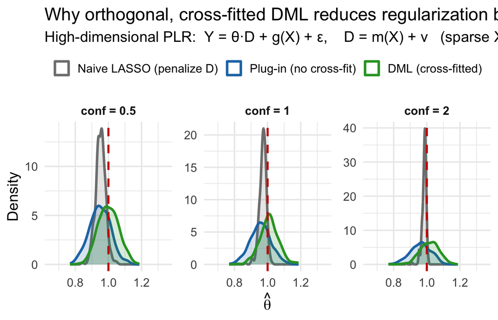

```r
# ---- dml_density_plot_chernozhukov_style ----
suppressPackageStartupMessages({
  library(glmnet); library(ggplot2); library(dplyr); library(tidyr); library(purrr)
})

set.seed(123)

## 1) High-dimensional partially linear DGP
##    Y = θ0 * D + g(X) + ε,   D = m(X) + ν,  X ∈ R^p with sparse signals
simulate_plr <- function(n = 500, p = 200, s = 10, theta0 = 1, conf_strength = 1) {
  X <- matrix(rnorm(n * p), n, p); colnames(X) <- paste0("x", 1:p)
  idx_g <- sample.int(p, s); beta_g <- numeric(p); beta_g[idx_g] <- rnorm(s, sd = 1)
  idx_m <- sample.int(p, s); beta_m <- numeric(p); beta_m[idx_m] <- rnorm(s, sd = 1)

  gX <- as.vector(X %*% beta_g)
  mX <- as.vector(conf_strength * (X %*% beta_m))  # scale confounding

  v <- rnorm(n); eps <- rnorm(n)
  D <- mX + v
  Y <- theta0 * D + gX + eps
  list(Y = Y, D = D, X = X, theta0 = theta0)
}

## 2) Estimators
# 2.1 Naive LASSO that penalizes D -> shrinkage bias toward 0
est_naive_lasso <- function(Y, D, X){
  Z <- cbind(D = D, X)
  fit <- cv.glmnet(Z, Y, alpha = 1, standardize = TRUE,
                   penalty.factor = rep(1, ncol(Z)))        # penalize D too
  as.numeric(coef(fit, s = "lambda.min")[2])                  # coef on D
}

# 2.2 Plug-in w/out cross-fitting: partial out on same sample -> regularization bias
est_plugin_noCF <- function(Y, D, X){
  fitY <- cv.glmnet(X, Y, alpha = 1, standardize = TRUE)
  fitD <- cv.glmnet(X, D, alpha = 1, standardize = TRUE)
  muhat <- as.numeric(predict(fitY, X, s = "lambda.min"))
  mhat  <- as.numeric(predict(fitD, X, s = "lambda.min"))
  ytil  <- Y - muhat
  dtil  <- D - mhat
  coef(lm(ytil ~ dtil))[2]
}

# 2.3 DML: cross-fitted partialling-out (K=2)
est_dml <- function(Y, D, X, K = 2){
  n <- length(Y); folds <- sample(rep(1:K, length.out = n))
  ytil <- numeric(n); dtil <- numeric(n)
  for(k in 1:K){
    tr <- which(folds != k); te <- which(folds == k)
    fitY <- cv.glmnet(X[tr, , drop=FALSE], Y[tr], alpha = 1, standardize = TRUE)
    fitD <- cv.glmnet(X[tr, , drop=FALSE], D[tr], alpha = 1, standardize = TRUE)
    muhat <- as.numeric(predict(fitY, X[te, , drop=FALSE], s = "lambda.min"))
    mhat  <- as.numeric(predict(fitD, X[te, , drop=FALSE], s = "lambda.min"))
    ytil[te] <- Y[te] - muhat
    dtil[te] <- D[te] - mhat
  }
  as.numeric(coef(lm(ytil ~ dtil))[2])
}

## 3) Monte-Carlo across confounding strengths
run_mc <- function(conf_strength, reps = 300, n = 500, p = 200, s = 10, theta0 = 1){
  tibble(rep = 1:reps) |>
    mutate(sim = map(rep, ~ simulate_plr(n, p, s, theta0, conf_strength))) |>
    mutate(
      naive = map_dbl(sim, ~ est_naive_lasso(.$Y, .$D, .$X)),
      plug  = map_dbl(sim, ~ est_plugin_noCF(.$Y, .$D, .$X)),
      dml   = map_dbl(sim, ~ est_dml(.$Y, .$D, .$X))
    ) |>
    select(-sim) |>
    mutate(conf = factor(paste0("conf = ", conf_strength)))
}

conf_grid <- c(0.5, 1.0, 2.0)
mc <- map_df(conf_grid, ~ run_mc(.x, reps = 300))

mc_long <- mc |>
  pivot_longer(cols = c(naive, plug, dml),
               names_to = "method", values_to = "theta_hat") |>
  mutate(
    method = factor(method,
                    levels = c("naive", "plug", "dml"),
                    labels = c("Naive LASSO (penalize D)",
                               "Plug-in (no cross-fit)",
                               "DML (cross-fitted)"))
  )

## 4) Density-style plot (clean typography; true θ line; clear legend)
theta0 <- 1.0
x_center <- theta0; x_span <- 0.35
x_lim <- c(x_center - x_span, x_center + x_span)

cols <- c("Naive LASSO (penalize D)" = "#7f7f7f",
          "Plug-in (no cross-fit)"   = "#1f77b4",
          "DML (cross-fitted)"       = "#2ca02c")

p_den <- ggplot(mc_long, aes(x = theta_hat, colour = method, fill = method)) +
  geom_density(alpha = 0.18, adjust = 1.0, linewidth = 1.2) +
  geom_vline(xintercept = theta0, linetype = "dashed", colour = "red3", linewidth = 1) +
  facet_wrap(~ conf, nrow = 1, scales = "free_y") +
  scale_color_manual(values = cols, name = NULL) +
  scale_fill_manual(values = cols, guide = "none") +
  coord_cartesian(xlim = x_lim) +
  labs(title = "Why orthogonal, cross-fitted DML reduces regularization bias",
       subtitle = "High-dimensional PLR:  Y = θ·D + g(X) + ε,    D = m(X) + ν   (sparse X).   Red dashed = true θ₀",
       x = expression(hat(theta)), y = "Density") +
  theme_minimal(base_size = 15) +
  theme(strip.text = element_text(face = "bold"),
        legend.position = "top",
        panel.spacing.x = unit(12, "pt"))

print(p_den)
```